# Project 2 B Approach

Author

Samantha Barbaro

## Approach

here’s the data set: https://raw.githubusercontent.com/acatlin/data/refs/heads/master/penguin_predictions.csv

I will load data set into R. Then, I will Calculate the null error rate by finding out which class is the minority (male vs. female) then dividing minority class by total sample set.

I will create three confusion matrices using an appropriate graphing package (possibly carret) using probability thresholds of 0.2, 0.5, and 0.8.

I will discuss when a low probability threshold is preferable (more false positives), e.g. during breast cancer screening (mammograms have a lot of false positives) or with a carbon monoxide monitor as opposed to a high probability threshold, when more false negatives are preferable (lower-stakes situations), like with credit card fraud, websites that constantly ask if you are a robot, or subscription services detecting that you’re using a VPN.

## Loading the data aset

```r
library(tidyverse)
penguins_url <- "https://raw.githubusercontent.com/acatlin/data/refs/heads/master/penguin_predictions.csv"

#read and convert blanks and NULL to NA

penguins <- read.csv(penguins_url, na = c("", "NA", "null", "NULL"))
```

## Exploring the data

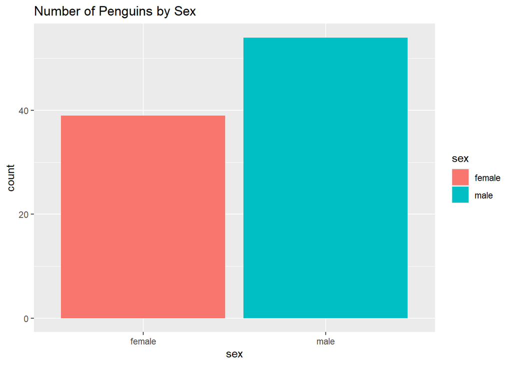

```r
ggplot(data = penguins, aes(x = sex, fill = sex)) + geom_bar() + labs (title = "Number of Penguins by Sex")
```

## Null error rate

Calculate null error rate by finding out which class is the minority (male vs. female) then dividing minority class by total sample set.

```r
 #checking the count of male and female, the majority class is male, and the total sample size is 93
penguins |> count(sex)
```

```
     sex  n
1 female 39
2   male 54
```

```r
#the minority class is female (39 penguins vs. 54)

39/93
```

```
[1] 0.4193548
```

```r
#the null error rate is .419 or 41.9%
```